# Portfolio assignment 1: Using mixed effects modelling to model hierarchical data

MARTIN THOMSEN

15-11-2021

# Assignment 1: Using mixed effects modelling to model hierarchical data

In this assignment we will be investigating the *politeness* dataset of Winter and Grawunder (2012) and apply basic methods of multilevel modelling.

Loading packages and omitting missing data:

```r
politeness <- read.csv('politeness.csv')
 ## read in data
library(dplyr)
library(lme4)
library(tidyverse)
library(car)
politeness=na.omit(politeness)
```

## Exercise 1 - describing the dataset and making some initial plots

1. Describe the dataset, such that someone who happened upon this dataset could understand the variables and what they contain

A study was conducted to ascertain whether Korean native speakers change their pitch, as a result of speaking in formal or informal scenarios. Seven different scenarios were acted out, where each participant responded to both a formal and informal setup. 16 participants (9 females and 7 males) completed the scenarios and were scored on a number of variables.

There are seven variables contained within the dataset: Subject: The identifier of each participant, where ‘F’ indicates a female participant and ‘M’ a male participant. Gender: The gender of the participant (female or male). This is a factor with two levels and is therefore transformed:

```r
politeness$gender<- factor(politeness$gender)
```

Scenario: Each participant has completed seven scenarios, which require the participant to speak in a formal or informal manner. Scenarios are given a integer (1-7) as an identifier. Attitude: Attitude denotes whether or not the participant is speaking in a formal or informal manner. This is a factor and must therefore be transformed:

```r
politeness$attitude<- factor(politeness$attitude)
```

Total duration: Time taken for each participant to complete their interaction. f0mn: Base frequency of the pitch of each participant (mean of pitch in sentence; Hz). hiss_count: Number of time each participant takes an audible breath.

2. Create a new data frame that just contains the subject *F1* and run two linear models; one that expresses *f0mn* as dependent on *scenario* as an integer; and one that expresses *f0mn* as dependent on *scenario* encoded as a factor

```r
df.F1 <- data.frame(filter(politeness, subject == "F1"))

regF1_integer = lm(f0mn~scenario, data = df.F1)

df.F1$scenario_factor <- factor(df.F1$scenario)
regF1_factor = lm(f0mn~scenario_factor, df.F1)

print(summary(regF1_integer))
```

```
##
## Call:
## lm(formula = f0mn ~ scenario, data = df.F1)
##
## Residuals:
##     Min      1Q  Median      3Q     Max
## -44.836 -36.807   6.686  20.918  46.421
##
## Coefficients:
##             Estimate Std. Error t value Pr(>|t|)
## (Intercept)  262.621     20.616  12.738 2.48e-08 ***
## scenario      -6.886      4.610  -1.494    0.161
## ---
## Signif. codes:  0 '***' 0.001 '**' 0.01 '*' 0.05 '.' 0.1 ' ' 1
##
## Residual standard error: 34.5 on 12 degrees of freedom
## Multiple R-squared:  0.1568, Adjusted R-squared:  0.0865
## F-statistic: 2.231 on 1 and 12 DF,  p-value: 0.1611
```

```r
print(summary(regF1_factor))
```

```
##
## Call:
## lm(formula = f0mn ~ scenario_factor, data = df.F1)
##
## Residuals:
##    Min     1Q Median     3Q    Max
## -37.50 -13.86   0.00  13.86  37.50
##
## Coefficients:
##                  Estimate Std. Error t value Pr(>|t|)
## (Intercept)        212.75      20.35  10.453  1.6e-05 ***
## scenario_factor2    62.40      28.78   2.168   0.0668 .
## scenario_factor3    35.35      28.78   1.228   0.2591
## scenario_factor4    53.75      28.78   1.867   0.1041
## scenario_factor5    27.30      28.78   0.948   0.3745
## scenario_factor6    -7.55      28.78  -0.262   0.8006
## scenario_factor7   -14.95      28.78  -0.519   0.6195
## ---
## Signif. codes:  0 '***' 0.001 '**' 0.01 '*' 0.05 '.' 0.1 ' ' 1
##
## Residual standard error: 28.78 on 7 degrees of freedom
## Multiple R-squared:  0.6576, Adjusted R-squared:  0.364
## F-statistic:  2.24 on 6 and 7 DF,  p-value: 0.1576
```

1. Include the model matrices, $X$ from the General Linear Model, for these two models in your report and describe the different interpretations of *scenario* that these entail For the linear model using scenario as a factor, it assumes that each scenario is qualitatively different.

```r
model.matrix(regF1_factor, data = df.F1)
```

```
##    (Intercept) scenario_factor2 scenario_factor3 scenario_factor4
## 1            1                0                0                0
## 2            1                0                0                0
## 3            1                1                0                0
## 4            1                1                0                0
## 5            1                0                1                0
## 6            1                0                1                0
## 7            1                0                0                1
## 8            1                0                0                1
## 9            1                0                0                0
## 10           1                0                0                0
## 11           1                0                0                0
## 12           1                0                0                0
## 13           1                0                0                0
## 14           1                0                0                0
```

[output cut: 20 more lines]

Using scenario as a factor is meaningless, as this only provides an estimated mean for each scenario (in effect, the linear model is composed of 7 horisontal lines). This can be easily calculated without using a linear model.

Using scenario as a nominal variable, it assumes they are quantitatively different.

```r
model.matrix(regF1_integer, data = df.F1)
```

```
##    (Intercept) scenario
## 1            1        1
## 2            1        1
## 3            1        2
## 4            1        2
## 5            1        3
## 6            1        3
## 7            1        4
## 8            1        4
## 9            1        5
## 10           1        5
## 11           1        6
## 12           1        6
## 13           1        7
## 14           1        7
## attr(,"assign")
## [1] 0 1
```

It is meaningless to assume that pitch in each scenario can be modelled based on a single scenario, i.e. scenario 4 can be predicted using information from scenario 1.

2. Which coding of *scenario*, as a factor or not, is more fitting?

As there is no obvious or intuitive link between performances on each scenario, i.e. that The hypothesis relates to changes in pitch in a formal/informal setting and therefore the changes in each scenario would be the outcome. Neither of these models inform us as researchers.

3. Make a plot that includes a subplot for each subject that has *scenario* on the x-axis and *f0mn* on the y-axis and where points are colour coded according to *attitude* i. Describe the differences between subjects

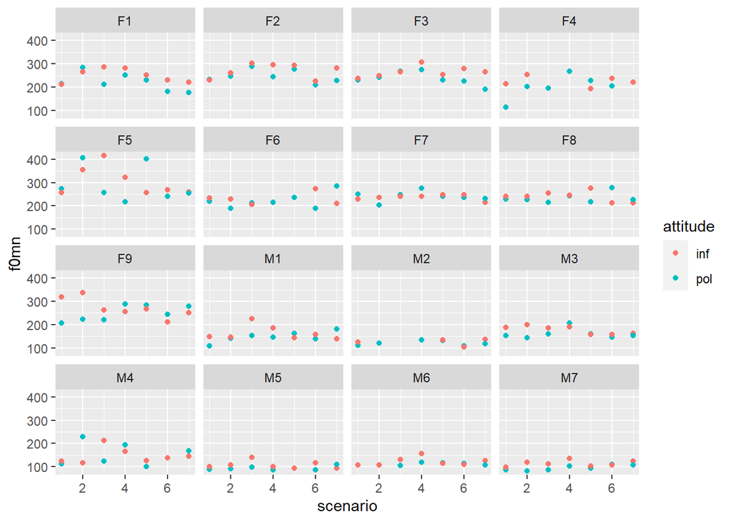

```r
ggplot(data = politeness, aes(x = scenario, y = f0mn, color = attitude)) +
  geom_point() +
  facet_wrap(~subject)
```

There is a clear difference between males and females in terms of base frequency. However, there are also differences between subjects. Subject F9 displayed a large frequency change in scenarios one and two, whereas F8 showed little or no difference. Overall, some subjects showed more variability than others.

## Exercise 2 - comparison of models

1. Build four models and do some comparisons
1. a single level model that models *f0mn* as dependent on *gender*

```r
single_Model <- lm(f0mn ~ gender, data = politeness)
```

2. a two-level model that adds a second level on top of i. where unique intercepts are modelled for each *scenario*

```r
model_intercept_scenario <- lmer(f0mn ~ gender + (1|scenario), data = politeness)
```

3. a two-level model that only has *subject* as an intercept

```r
model_intercept_subject <- lmer(f0mn ~ gender + (1|subject), data = politeness)
```

4. a two-level model that models intercepts for both *scenario* and *subject*

```r
twoLevel_Model <- lmer(f0mn ~ gender + (1|scenario) + (1|subject), data = politeness)
```

22. which of the models has the lowest residual standard deviation, also compare the Akaike Information Criterion ‘AIC’?

```r
tibble(sigma(single_Model), sigma(model_intercept_scenario), sigma(model_intercept_subject), sigma(twoLevel_Model))
```

| sigma(single_Model) | sigma(model_intercept_scenario) | sigma(model_intercept_subject) | sigma(twoLevel_Model) |
| --- | --- | --- | --- |
| 39.46268 | 38.448 | 32.04287 | 30.65803 |

```r
AIC(single_Model,model_intercept_scenario, model_intercept_subject, twoLevel_Model)
```

|  | df | AIC |
| --- | --- | --- |
| single_Model | 3 | 2163.971 |
| model_intercept_scenario | 4 | 2152.314 |
| model_intercept_subject | 4 | 2099.626 |
| twoLevel_Model | 5 | 2092.482 |

```
The lowest residual standard deviation, as well as lowest AIC, is found in the model including gender as a fixed effect and scenario and subject as random effects.
```

6. which of the second-level effects explains the most variance? Looking at the residuals and AIC again, it appears that subject accounts for more variance than scenario. The model including only subject as a random effect has a lower residual standard deviation and AIC, than scenario.
2. Why is our single-level model bad? Because it does not take random effects into account. As such, it assumes that changes in outcome come from a single variable, whereas a second level model takes random effects into account. This reduces the error term and provides more explanation for the variance observed.
1. create a new data frame that has three variables, *subject*, *gender* and *f0mn*, where *f0mn* is the average of all responses of each subject, i.e. averaging across *attitude* and_scenario_

```r
# RENAME SUBSET SO IT MAKES SENSE IN RELATION TO A GENDER MODEL
df.Subset = politeness %>%
  group_by(subject, gender)%>%
  summarise(base_pitch = mean(f0mn))
```

2. build a single-level model that models *f0mn* as dependent on *gender* using this new dataset

```r
# RENAME FOR GENDER MODEL
F1_Model = lm(base_pitch~gender, data = df.Subset)
```

3. make Quantile-Quantile plots, comparing theoretical quantiles to the sample quantiles) using ‘qqnorm’ and ‘qqline’ for the new single-level model and compare it to the old single-level model (from 1).i). Which model’s residuals ($\epsilon$) fulfill the assumptions of the General Linear Model better?)

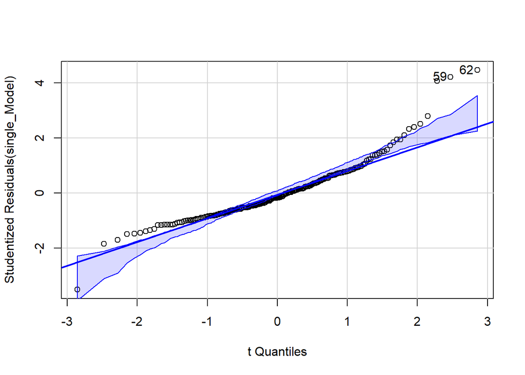

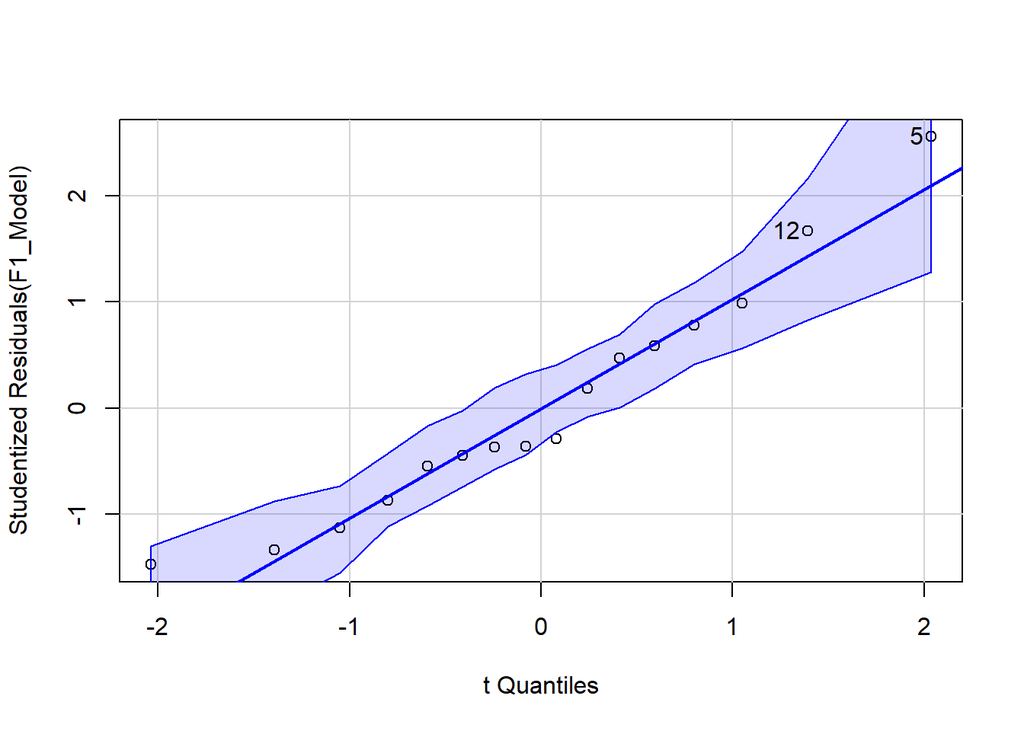

```r
par(qqPlot(single_Model), qqPlot(F1_Model))
```

```r
tibble(sigma(single_Model), sigma(F1_Model))
```

| sigma(single_Model) | sigma(F1_Model) |
| --- | --- |
| 39.46268 | 25.906 |

```r
# How to remove console output?
```

[output not shown]

4. Also make a quantile-quantile plot for the residuals of the multilevel model with two intercepts. Does it look alright?

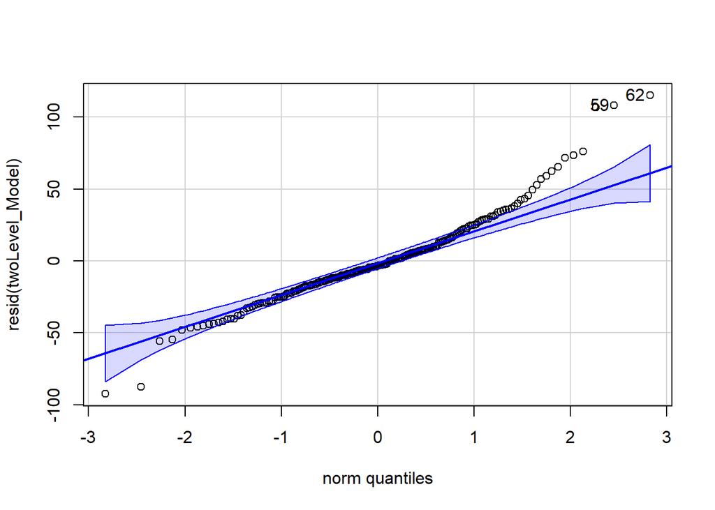

```
## 62 59
## 59 56
```

```r
qqPlot(resid(twoLevel_Model))
```

```r
# QQPLOT OUTPUT?

# hist(resid(twoLevel_Model))
```

QQ plot suggests that data is not normally distributed. Reasonably, data should be transformed before further processing.

3. Plotting the two-intercepts model
   1. Create a plot for each subject, (similar to part 3 in Exercise 1), this time also indicating the fitted value for each of the subjects for each for the scenarios.

```r
fixedEffect = fixef(twoLevel_Model)
randomEffect = ranef(twoLevel_Model)

fixedEffect
```

```
## (Intercept)     genderM
##    246.7650   -115.1746
```

```r
randomEffect
```

```
## $subject
##    (Intercept)
## F1  -10.490356
## F2   10.251809
## F3    3.795129
## F4  -29.495270
## F5   47.093999
## F6  -18.396273
## F7   -6.976691
## F8   -8.521934
## F9   12.739587
## M1   21.052117
## M2   -5.462358
## M3   33.561535
## M4   16.093337
## M5  -28.267430
## M6  -12.640202
## M7  -24.336998
##
## $scenario
##   (Intercept)
## 1  -11.595496
## 2    5.321218
## 3    6.795658
## 4   11.348815
## 5    1.411037
## 6   -8.622136
## 7   -4.659096
##
## with conditional variances for "subject" "scenario"
```

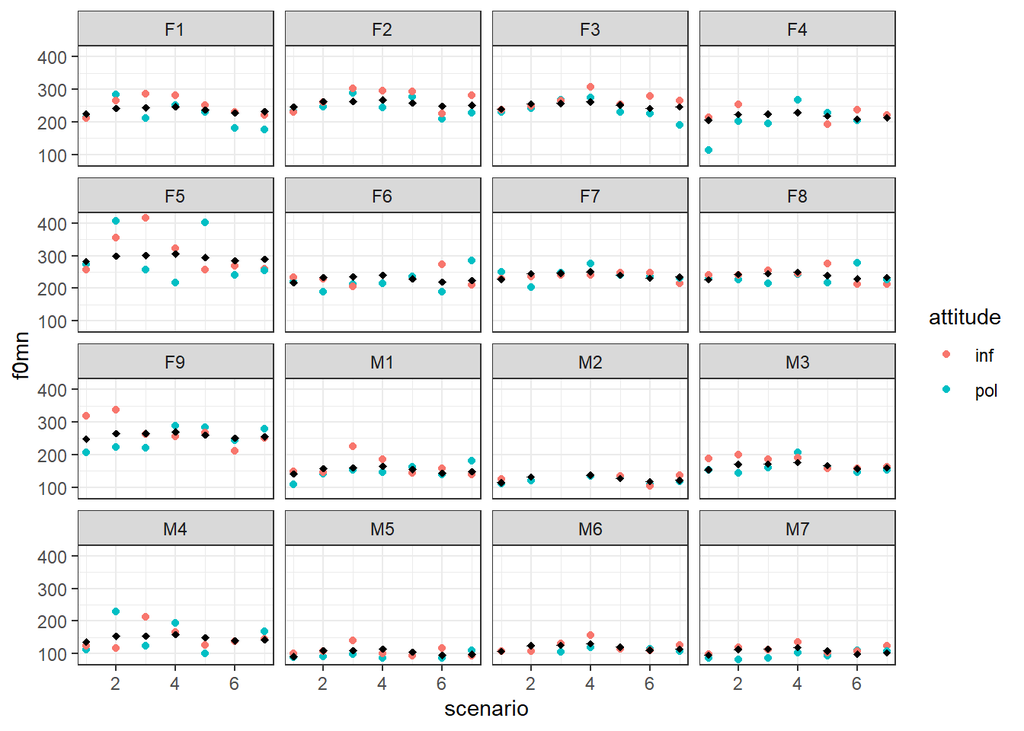

```r
# WHY SHOW THIS PLOT AND THESE VARIABLES?

ggplot(data = politeness, aes(x = scenario, y = f0mn, color = attitude)) +
  geom_point() +
  geom_point(aes(x = scenario, y = fitted(twoLevel_Model)), color = "black", shape = 18)+
  facet_wrap(~subject)+
  theme_bw()
```

## Exercise 3 - now with attitude

1. Carry on with the model with the two unique intercepts fitted (*scenario* and *subject*).
   1. now build a model that has *attitude* as a main effect besides *gender*

```r
attitude_Model <- lmer(f0mn ~ gender + attitude + (1|scenario) + (1|subject), data = politeness, REML = FALSE)
summary(attitude_Model)
```

```
## Linear mixed model fit by maximum likelihood  ['lmerMod']
## Formula: f0mn ~ gender + attitude + (1 | scenario) + (1 | subject)
##    Data: politeness
##
##      AIC      BIC   logLik deviance df.resid
##   2094.5   2114.6  -1041.2   2082.5      206
##
## Scaled residuals:
##     Min      1Q  Median      3Q     Max
## -2.8791 -0.5968 -0.0569  0.4260  3.9068
##
## Random effects:
##  Groups   Name        Variance Std.Dev.
##  subject  (Intercept) 514.92   22.692
##  scenario (Intercept)  99.22    9.961
##  Residual             878.39   29.638
## Number of obs: 212, groups:  subject, 16; scenario, 7
##
## Fixed effects:
##             Estimate Std. Error t value
## (Intercept)  254.408      9.117  27.904
## genderM     -115.447     12.161  -9.494
## attitudepol  -14.817      4.086  -3.626
##
## Correlation of Fixed Effects:
##             (Intr) gendrM
## genderM     -0.583
## attitudepol -0.231  0.006
```

2. make a separate model that besides the main effects of *attitude* and *gender* also include their interaction

```r
full_Model <- lmer(f0mn ~ gender * attitude + (1|scenario) + (1|subject), data = politeness, REML = FALSE)
summary(full_Model)
```

```
## Linear mixed model fit by maximum likelihood  ['lmerMod']
## Formula: f0mn ~ gender * attitude + (1 | scenario) + (1 | subject)
##    Data: politeness
##
##      AIC      BIC   logLik deviance df.resid
##   2096.0   2119.5  -1041.0   2082.0      205
##
## Scaled residuals:
##     Min      1Q  Median      3Q     Max
## -2.8460 -0.5893 -0.0685  0.3946  3.9518
##
## Random effects:
##  Groups   Name        Variance Std.Dev.
##  subject  (Intercept) 514.09   22.674
##  scenario (Intercept)  99.08    9.954
##  Residual             876.46   29.605
## Number of obs: 212, groups:  subject, 16; scenario, 7
##
## Fixed effects:
##                     Estimate Std. Error t value
## (Intercept)          255.632      9.289  27.521
## genderM             -118.251     12.841  -9.209
## attitudepol          -17.198      5.395  -3.188
## genderM:attitudepol    5.563      8.241   0.675
##
## Correlation of Fixed Effects:
##             (Intr) gendrM atttdp
## genderM     -0.605
## attitudepol -0.299  0.216
## gndrM:tttdp  0.195 -0.323 -0.654
```

3. describe what the interaction term in the model says about Korean men’s pitch when they are polite relative to Korean women’s pitch when they are polite (you don’t have to judge whether it is interesting)

The model provides the information that the frequency lowers by 17.2 Hz when moving from an informal to a polite setting. When looking at the interaction between gender and attitude, it can be seen that the frequency of men increases by 5.6 Hz relative to the change of 17.2 Hz. This means that while women drop by 17.2 Hz, men only drop 11.6 Hz. As such, frequency changes less for men, when going from an informal to a polite setting.

2. Compare the three models (1. gender as a main effect; 2. gender and attitude as main effects; 3. gender and attitude as main effects and the interaction between them. For all three models model unique intercepts for *subject* and *scenario*) using residual variance, residual standard deviation and AIC.

```r
# USING A DIFFERENT METHOD OF SEPARATING THE MODELS
anova(twoLevel_Model, attitude_Model, full_Model)
```

```
## refitting model(s) with ML (instead of REML)
```

|  | npar | AIC | BIC | logLik | deviance | Chisq | Df | Pr(>Chisq) |
| --- | --- | --- | --- | --- | --- | --- | --- | --- |
| twoLevel_Model | 5 | 2105.176 | 2121.958 | -1047.588 | 2095.176 | NA | NA | NA |
| attitude_Model | 6 | 2094.489 | 2114.628 | -1041.244 | 2082.489 | 12.6867631 | 1 | 0.0003682532 |
| full_Model | 7 | 2096.034 | 2119.530 | -1041.017 | 2082.034 | 0.4551491 | 1 | 0.4998998177 |

3. Choose the model that you think describe the data the best - and write a short report on the main findings based on this model. At least include the following:
1. describe what the dataset consists of h
2. what can you conclude about the effect of gender and attitude on pitch (if anything)?
3. motivate why you would include separate intercepts for subjects and scenarios (if you think they should be included)
4. describe the variance components of the second level (if any) The second level effects, i.e. random effects, account for some of the error that would otherwise be attributed to epsilon. As such, it provides a model where there is more variance accounted for. The second level effects here, are subject and scenario.
5. include a Quantile-Quantile plot of your chosen model

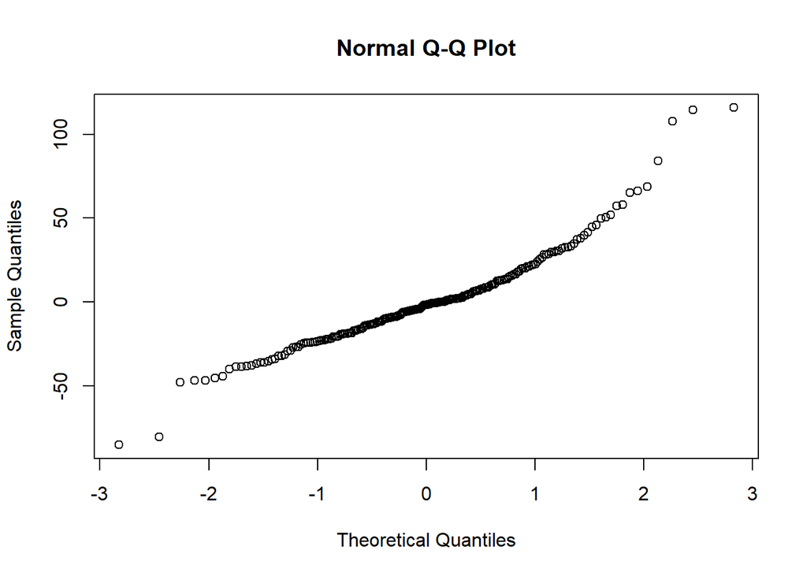

```r
#qqnorm(resid(attitude_Model))
attitude_Model%>%resid()%>%qqnorm()
```

```r
# hist(resid(attitude_Model))
# WHY HISTOGRAM?
```